# Using control structures with Sweave

Abstract

“Using control structures with Sweave” published in R News.

*Damian Betebenner*

Sweave is a tool loaded by default with the utils package that permits the integration of R/S with L<sup>A</sup>T<sub>E</sub>X. In one of its more prominant applications, Sweave enables literate statistical practice—where R/S source code is interwoven with corresponding L<sup>A</sup>T<sub>E</sub>X formatted documentation (R Development Core Team, 2005; Leisch, 2002a,b). A particularly elegant implementation of this is the `vignette()` function (Leisch, 2003). Another, more pedestrian, use of Sweave, which is the focus of this article, is the batch processing of reports whose contents, including figures and variable values, are dynamic in nature. Dynamic forms are common on the web where a base `.html` template is populated with user specific data drawn, most often, from a database. The incorporation of repetitive and conditional control structures into the processed files allows for almost limitless possibilities to weave together output from R/S within the confines of a L<sup>A</sup>T<sub>E</sub>X document and produce professional quality dynamic output.

Motivation for the current project came as a result of pilot data analyses for a state department of education. Dissemination of the analyses to schools in the state required the production of approximately 3,000 school reports documenting the results using school specific numbers/text, tables, and figures. The R/Sweave/L<sup>A</sup>T<sub>E</sub>X combination was deployed in various ways to produce prototype reports. This article provides details of the process so that others with similar document production needs can employ this combination of tools.

## Outline of Process

The production process is quite basic in its implementation: Sweave a file using an appropriate dataframe to create a `.tex` that includes appropriate output. Most users of Sweave would have little problem creating such a `.tex` file based upon a given dataframe. Adding the capacity to deal with numerous different dataframes is possible using basic control structures available in R. In general, there are two files necessary for the mass production of reports:

**`template.Rnw`** A template file that provides the template into which all the relevant R output is placed.

**`master.R`** A master file that loops over all the recipients of the template file, creates the subset of data to be used within the template file, Sweaves the template and saves the output to a recipient specific `.tex` file.

In the following, the essential parts of each of these files is discussed in detail:

### **`master.R`**

The `master.R` file implements a control structure *outside* of the Sweave process. This allows one to create a `.tex` file for each recipient. The key to the creation of these files is the creation of a distinct `outfile` for each unique recipient in the list. A basic `master.R` file which performs this looks like:

```
load(the.data.frame)
recip.list <- unique(the.data.frame$recipient)
for (name in recip.list){
  subset.data <- subset(the.data.frame,
                        the.data.frame$recipient==name)
  outfile <- paste(name, "tex", sep=".")
  Sweave("template.Rnw", output=outfile)
}
```

The process starts by sourcing `master.R`. This loads a master data frame that contains the data for all the potential report recipients. A list of recipients is then derived from that dataframe. A looping structure is implemented that subsets the appropriate data file from the master data frame. Crucially, this subsetted data frame contains the recipient specific data that is used to construct the individualized report. Finally, a recipient specific `.tex` file is created by by Sweaving the template, `template.Rnw`.

Depending upon the number of recipients, it is entirely possible for thousands of `.tex` files to be generated. To avoid the files accumulating in the same directory, one can easily modify the code to place the output in other directories. For example, if one wished to create a distinct directory for each recipient, the following additions would suffice:

```
for (name in recip.list){
  subset.data <- subset(the.data.frame,
                        the.data.frame$recipient==name)
  outfile <- paste(name, "tex", sep=".")
  dir.create(name)
  setwd(name)
  Sweave(file.path("..", "template.Rnw"),
          output=outfile)
  setwd("..")
}
```

This basic control structure can be tweaked in many ways. For example, a call can be made to a relational database that pulls the relevant data into R for processing. This is particularly attractive for those applications where data storage is cumbersome and better administered with a relational database.

### **`template.Rnw`**

The template, `template.Rnw`, is a standard Sweave file containing L<sup>A</sup>T<sub>E</sub>X markup together with documentation and code chunks. The file, as its name suggests, is a template into which recipient specific numbers/text, tables, and figures can be included. One of the greatest challenges to producing a template is ensuring that it will produce the expected output given the range of possible values it is expected to accept.

One of the easiest ways of providing recipient specific output with the `template.Rnw` file is through the liberal use of the `\Sexpr` function. For the aforementioned school reports, the name of the school was included throughout the text, tables, and figures to provide a customized feel. In particular, the fancy-hdr L<sup>A</sup>T<sub>E</sub>X package was used and the school name was included in the left header. Because school names, and string expressions in general, vary widely in their length, care must be exercised so that any place that the `\Sexpr` is utilized, the string (or number) resulting from `\Sexpr` will function in the L<sup>A</sup>T<sub>E</sub>X document for the range of values of the field that occur in the data set.

The creation of recipient specific tables is a frequently encountered (particularly with `.html`) means of dynamic report generation. There are a number of ways of including tables into the `template.Rnw` document. Perhaps the simplest way is through the use of the `xtable` function within David Dahl’s `xtable` package which produces $\LaTeX$ output for a variety of R objects. A basic code chunk yielding `.tex` markup producing a table is given by

```
<<echo=FALSE,results=tex>>=
xtable(object, caption="table:caption",
       label="table:label")
@
```

Though suitable for a variety of tasks, the function `xtable` is limited in its capacity to produce complex tables (e.g., tables with multicolumn headers). Another frequently encountered difficulty occurs when tables being produced are long and possibly extend over several pages. Such long tables are not a problem with `|.html|` because the pages can be of nearly infinite length. However, printed pages must have the table broken into pieces according to the space available on the page. The $\LaTeX$ code produced by `xtable` will not yield acceptable results. To circumvent this, one can use the `latex.table` function provided by Roger Koenker’s `quantreg` package together with the option for using the `longtable` $\LaTeX$ package. The `latex.table` function accepts matrix objects and outputs results to a specified file. As such, its incorporation into the Sweave document requires a slightly different two part technique than that used with `xtable`:

1. 1. `latex.table` is called within a code chunk and produces the required $\LaTeX$ markup and saves it to an output file.

```
<<echo=FALSE>>=
latex.table(matrix,
            file=paste(name, ":table.tex",
                        sep=""))
@
```

1. 2. The $\LaTeX$ markup for the table is inserted into the document (n.b., outside of a code chunk) at the appropriate place:

```
\begin{center}
\input{\Sexpr{name}:table.tex}
\end{center}
```

As with `xtable`, there are still limitations to the amount of tabular complexity available with `latex.table`. Multicolumn headings, multirow headings, colored columns, etc. are all difficult if not impossible to produce. Depending upon ones willingness to program, however, all effects can ultimately be produced. Though tedious, frequent use of `Sexpr` commands outside of code chunks or `cat` commands within code chunks allows all $\LaTeX$ commands to be incorporated into the final `.tex` document upon Sweave compilation.

In many instances, particularly with tables and figures, it’s necessary to produce multiple tables or figures within a single Sweave document based upon particular attributes of the recipient. For example, with the school project each school’s report contained information pertinent to each grade in the school. Thus, a table was produced for each grade within the school. To implement this, a loop is placed *within* `template.Rnw`. This procedure, given in FAQ A.8 from Friedrich Leisch’s Sweave User Manual (Leisch, 2005), is useful in many situations.

A major difficulty with control structures within the template is the variable nature of the output. In the example with school reports, some rural schools have grades 1 through 12. Thus, if a table or figure is produced for each grade, one must take account of the fact that so many tables or figures will result in the `.tex` document. The simplest way to accommodate different numbers of loop iterations within the template is to create a `\newpage` each time the loop completes. Thus, for example, each figure for each grade receives a page to itself. This doesn’t always look acceptable for especially parsimonious tables or figures. However, combining multiple tables on a single page can often cause overfull `hbox` and `vbox` situations to occur. A workaround to this difficulty is to use the $\LaTeX$ `\scalebox` and `\resizebox` commands. These commands allow great flexibility in shrinking output to fit a given page. In general, a good deal of planning and experimentation is necessary to produce a template that works well for all situations.

The extent to which one wishes to make the reports specific to a particular recipient can be extended far beyond expressing the recipient specific information in tables and figures. For reports where the recipient is an individual, text within the report can be made gender specific through the use of `if else` statements based upon values in the subsetted data frame that the template is using to construct the recipient specific report. Supposing the gender code in the subsetted data frame is 1 for males and 2 for females, one could incorporate `he/she` (or `him/her`) pronouns into the text using a simple `if else` statement such as

```
\Sexpr{if (data.frame$gender==1) "he"
        else "she"}
```

The amount of customization is limited only by the amount of work put into constructing the template.

One is not limited to the basic $\LaTeX$ classes (e.g., `article.cls` or `report.cls`) when producing the template. The `beamer.cls` (Tantau, 2004) is Sweave compatible and provides extensive functionality to produce rich, full color `.pdf` output with extensive hyperlink capabilities. Figure 1 presents a two page example demonstrating some possibilities of the R/$\LaTeX$/Sweave combination for dynamic `.pdf` report generation using the `beamer.cls`. Other

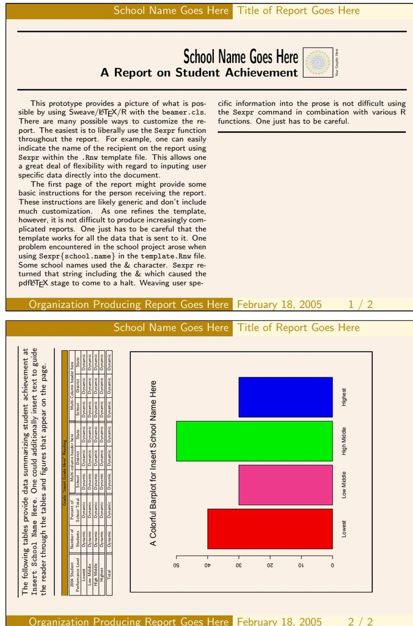

Figure 1: A basic two-page example demonstrating dynamic .pdf using the R/L<sup>A</sup>T<sub>E</sub>X/Sweave combination.

L<sup>A</sup>T<sub>E</sub>X classes, packages and font families are available that can be combined to yield unlimited possibilities.

## Final Compilation

Upon Sweave completion, `master.R` yields numerous `.tex` files that need to be compiled. For the school project, approximately 3,000 `.tex` files were created. In addition, there were, in most cases, three `.pdf` figures created for each school. All of these files can be compiled from within R using the `texi2dvi` command available in the `tools` package. The fol lowing loop which can be placed into `master.R` accomplishes this task:

```
for (name in recip.list){
    outfile <- paste(name, "tex", sep=".")
    texi2dvi(outfile, pdf=TRUE, clean=TRUE)
}
```

`texi2dvi` will run L<sup>A</sup>T<sub>E</sub>X and BIBT<sub>E</sub>X the appropriate number of times to resolve any reference and citation dependencies. The result is compiled versions of all the `.tex` files generated from the earlier loop containing the Sweave process. It is also possible to perform this task outside of R using a script or batch file to perform the same operations.

## Conclusions

For batch production of dynamic .pdf or .ps documentation, the R/Sweave/$\LaTeX$ combination is powerful and nearly limitless in its capabilities. A major benefit to producing reports using this combination of tools is how closely Sweave integrates the processing power of R with the typesetting capability of $\LaTeX$. The key to producing dynamic reports for a large number of recipients is the use of iterative control structures in R. This article provides the author’s “homebrew” code. Other, more elegant, solutions are likely possible.

A next step after report generation is report distribution. In theory, given the appropriate server configuration, it should be possible to electronically distribute the reports to the appropriate recipient based upon, for example, an email address contained in the database. I would appreciate learning how others have addressed this and similar problems.

## Acknowledgments

I would like to thank Bill Oliver for introducing me to R and for his gracious help. In addition, I would like to thank one of the reviewers for providing particularly insightful improvements to my code. Finally, I would like to express gratitude to the developers/contributors of R, Sweave, and $\LaTeX$, without their efforts none of this would be possible.

## References

- F. Leisch. Sweave: Dynamic generation of statistical reports using literate data analysis. In W. Härdle and B. Rönz, editors, *Compstat 2002—Proceedings in Computational Statistics*, pages 575–580, Heidelberg, Germany, 2002a. Physika Verlag. ISBN 3-7908-1517-9. URL http://www.ci.tuwien.ac.at/~leisch/Sweave.
- F. Leisch. Sweave, Part I: Mixing R and $\LaTeX$. *R News*, 2(3):28–31, December 2002b. URL http://cran.r-project.org/doc/Rnews/Rnews_2002-3.pdf.
- F. Leisch. Sweave, Part II: Package Vignettes. *R News*, 3(2):21–24, October 2003. URL http://cran.r-project.org/doc/Rnews/Rnews_2003-2.pdf.
- F. Leisch. *Sweave User Manual*, 2005.
- R Development Core Team. *R: A language and environment for statistical computing*. R Foundation for Statistical Computing, Vienna, Austria, 2005. URL http://www.R-project.org. 3-900051-07-0.
- T. Tantau. *User’s Guide to the Beamer Class*. Sourceforge.net, 2004. URL http://latex-beamer.sourceforge.net.